# MC test proportions

### **NOTES ON STATISTICS, PROBABILITY and MATHEMATICS**

### Confirming Z test with Monte Carlo:

**DATA:**

```
           Medication
Symptoms    Drug A Drug B Totals
  Heartburn     64     92    156
  Normal       114     98    212
  Totals       178    190    368
```

**TEST STATISTIC FUNCTION IN R:**

For reference: $Z = \frac{\frac{x_1}{n_1}-\frac{x_2}{n_2}}{\sqrt{p\,(1-p)(1/n_1+1/n_2)}}$ with $p = \frac{x_1\,+\,x_2}{n_1\,+\,n_2}$

```
z.prop = function(x1,x2,n1,n2){
  numerator = (x1/n1) - (x2/n2)
  p.common = (x1+x2) / (n1+n2)
  denominator = sqrt(p.common * (1-p.common) * (1/n1 + 1/n2))
  z.prop.ris = numerator / denominator
  return(z.prop.ris)
}
```

**POPULATION SET UP WITH ONE SINGLE (AVERAGE) TRUE PROPORTION:**

```
set.seed(5)

# Number of samples taken to obtain different proportions IF we set it up so that the proportions are actually equal:

samples <- 100000

# Number of cases for Drug A and Drug B:

n1 <- 178
n2 <- 190

# Proportion of patients with heartburn:
p1 <- 64/n1
p2 <- 92/n2

# We will make up a population where the proportion of heartburn suffers is in between p1 and p2:

(c(p <- mean(c(p1, p2)), p1, p2))
[1] 0.4218805 0.3595506 0.4842105

# And we'll take samples of the size of the groups assigned to Drug A and Drug B respectively:

x1 <- rbinom(samples, n1, p)
x2 <- rbinom(samples, n2, p)

# Double - checking that the proportion is kept although the number of successes is different:

(c(mean(x1),mean(x2)))
[1] 75.08542 80.15841
(c(prop1 <- mean(x1)/n1, prop2 <- mean(x2)/n2, p))
[1] 0.4218282 0.4218864 0.4218805
```

**SIMULATION:**  
# Now we run the z-test in what we just did, but we repeat it 100000 times and put the results in vector pval:

```
pval <- 0
for (i in 1:100000) {
    pval[i] <- pnorm(-abs(z.prop(mean(x1[i]), mean(x2[i]), n1, n2)))
}

mean(pval <= .05)
[1] 0.09887
```

**So what is wrong with this simulation? The value should be below $0.05$ and it is not…**

The [probability integral function](https://en.wikipedia.org/wiki/Probability_integral_transform) dictates that if $X \sim N(\mu,\sigma^2)$, the random variable $Y = \Phi(X)$ with $\Phi$ corresponding to the [error function](https://en.wikipedia.org/wiki/Error_function) ($erf$) (who came up with this name?) will be uniformely distributed as $Y \sim U(a,b)$.

Since we know that the $p-values$ range from $(0,1)$, plotting the histogram should illustrate our expectation (overabundant $p<0.05$ values colored in greenish hue):

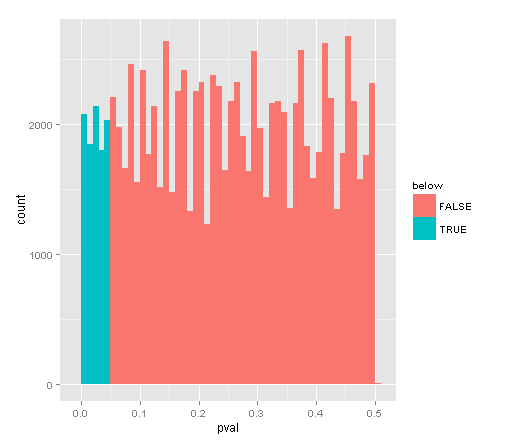

So we are getting just half of the span we expected: from $[0,0.5]$, as opposed to $[0,1]$. And the problem is in the code treatment of the $z$ values produced by the function `z.prop`. Since $z$ is a symmetric distribution the part of the code intended to “look up the probability in the table at the end of the book”: (`pnorm(-abs(z.prop(mean(x1[i]), mean(x2[i]), n1, n2)))`) is effectively sending all the $z$ values above $0$ to the negative part of the bell curve, and we end up with double amount of `pval < 0.05`.

If you happened to get a $z=1.4$, “you are calculating $Pr(Z<−1.4)$ when you should be calculating $Pr(Z<−1.4)+Pr(Z>1.4)$.

This can be fixed by simply doubling the value of the pvalues. Or perhaps more neatly by changing the **SIMULATION** part of the code in the OP to:

```
pval <- 0
for (i in 1:100000) {
     pval[i] <- pnorm(z.prop(mean(x1[i]), mean(x2[i]), n1, n2))
}
> mean(pval <= .025) + mean(pval >= 0.975)
[1] 0.04923
```

[Home Page](http://rinterested.github.io/statistics/index.html)

**NOTE: These are tentative notes on different topics for personal use - expect mistakes and misunderstandings.**